# Airbnb_price_analysis_project

tonghua.lin@rutgers.edu

4/28/2024

## R Markdown

Besides the chain hotels, Airbnb is another way to find a lodge while traveling. This project is trying to find the factors that can influence the price of a lodge, especially the location and city of a lodge. This can help to find a good place for holiday trips.

1.Explain the data collection process The data set is downloaded from Kaggle. It originally contains 29 columns and around 73000 rows, but needs to be cleaned up. Several description text type variables are excluded for data analysis. Also, neighbourhood and zipcode is excluded because the data set has latitude and longitude for location, while it’s hard to divided various neighbourhood and zipcode as category variables.

```r
library(readr)
DataSet <- read_csv("Airbnb_Data.csv")
# Set the ID as the name of rows, exclude some descriptive columns
DataSet$id <- NULL
DataSet$amenities <- NULL
DataSet$description <- NULL
DataSet$name <- NULL
DataSet$thumbnail_url <- NULL
DataSet$neighbourhood <- NULL
DataSet$zipcode <-NULL

head(DataSet)
```

```
## # A tibble: 6 × 22
##   log_price property_type room_type       accommodates bathrooms bed_type
##       <dbl> <chr>         <chr>                  <dbl>     <dbl> <chr>
## 1      5.01 Apartment     Entire home/apt            3         1 Real Bed
## 2      5.13 Apartment     Entire home/apt            7         1 Real Bed
## 3      4.98 Apartment     Entire home/apt            5         1 Real Bed
## 4      6.62 House         Entire home/apt            4         1 Real Bed
## 5      4.74 Apartment     Entire home/apt            2         1 Real Bed
## 6      4.44 Apartment     Private room               2         1 Real Bed
## # ℹ 16 more variables: cancellation_policy <chr>, cleaning_fee <lgl>,
## #   city <chr>, first_review <date>, host_has_profile_pic <lgl>,
## #   host_identity_verified <lgl>, host_response_rate <chr>, host_since <date>,
## #   instant_bookable <lgl>, last_review <date>, latitude <dbl>,
## #   longitude <dbl>, number_of_reviews <dbl>, review_scores_rating <dbl>,
## #   bedrooms <dbl>, beds <dbl>
```

```r
# Check the NA data rows
sapply(DataSet, function(x) sum(is.na(x)))
```

```
##              log_price          property_type              room_type
##                      0                      0                      0
##           accommodates              bathrooms               bed_type
##                      0                    200                      0
##    cancellation_policy           cleaning_fee                   city
##                      0                      0                      0
##           first_review   host_has_profile_pic host_identity_verified
##                  15864                    188                    188
##     host_response_rate             host_since       instant_bookable
##                  18299                    188                      0
##            last_review               latitude              longitude
##                  15827                      0                      0
##      number_of_reviews   review_scores_rating               bedrooms
##                      0                  16722                     91
##                   beds
##                    131
```

From the NA check, we can see that there are lots of missing data. For bathrooms, we can set NA as 0. For first_review data, there are many NAs. That means they are never rented out, or no one give a review. Similar situation can be found in last_review, host_response_rate, review_score_rating. We can use the host_since date for the missing part. For the NA in host_since, we can see then number of missing rows is exactly same with host_identity_verified, and it’s small. Let’s drop these rows. For date variables, we can use 2017/11/01 as the baseline to calculate the interval. It can change the date variables to numerical variables.

```r
# Remove rows with na host_identity_verified
DataSet <- DataSet[!is.na(DataSet$host_identity_verified),]
# Set na bathrooms to 0
DataSet$bathrooms[is.na(DataSet$bathrooms)] <- 0
# Use the host_since date for the na date
DataSet$first_review[is.na(DataSet$first_review)] <- DataSet$host_since[is.na(DataSet$first_review)]
DataSet$last_review[is.na(DataSet$last_review)] <- DataSet$host_since[is.na(DataSet$last_review)]
baslineDate <- as.Date('2017/11/01')
DataSet$first_review <- as.numeric(difftime(baslineDate, DataSet$first_review, units = "days"))
DataSet$last_review <- as.numeric(difftime(baslineDate, DataSet$last_review, units = "days"))
DataSet$host_since <- as.numeric(difftime(baslineDate, DataSet$host_since, units = "days"))
# Use mean for na host_response_rate and scores
DataSet$host_response_rate <- as.numeric(gsub("%", "", DataSet$host_response_rate))
DataSet$host_response_rate[is.na(DataSet$host_response_rate)] <- mean(DataSet$host_response_rate[!is.na(DataSet$host_response_rate)])
DataSet$review_scores_rating[is.na(DataSet$review_scores_rating)] <- mean(DataSet$review_scores_rating[!is.na(DataSet$review_scores_rating)])
DataSet$bedrooms[is.na(DataSet$bedrooms)] <- 1
DataSet$beds[is.na(DataSet$beds)] <- round(mean(DataSet$beds[!is.na(DataSet$beds)]))
sapply(DataSet, function(x) sum(is.na(x)))
```

```
##              log_price          property_type              room_type
##                      0                      0                      0
##           accommodates              bathrooms               bed_type
##                      0                      0                      0
##    cancellation_policy           cleaning_fee                   city
##                      0                      0                      0
##           first_review   host_has_profile_pic host_identity_verified
##                      0                      0                      0
##     host_response_rate             host_since       instant_bookable
##                      0                      0                      0
##            last_review               latitude              longitude
##                      0                      0                      0
##      number_of_reviews   review_scores_rating               bedrooms
##                      0                      0                      0
##                   beds
##                      0
```

```r
head(DataSet)
```

```
## # A tibble: 6 × 22
##   log_price property_type room_type       accommodates bathrooms bed_type
##       <dbl> <chr>         <chr>                  <dbl>     <dbl> <chr>
## 1      5.01 Apartment     Entire home/apt            3         1 Real Bed
## 2      5.13 Apartment     Entire home/apt            7         1 Real Bed
## 3      4.98 Apartment     Entire home/apt            5         1 Real Bed
## 4      6.62 House         Entire home/apt            4         1 Real Bed
## 5      4.74 Apartment     Entire home/apt            2         1 Real Bed
## 6      4.44 Apartment     Private room               2         1 Real Bed
## # ℹ 16 more variables: cancellation_policy <chr>, cleaning_fee <lgl>,
## #   city <chr>, first_review <dbl>, host_has_profile_pic <lgl>,
## #   host_identity_verified <lgl>, host_response_rate <dbl>, host_since <dbl>,
## #   instant_bookable <lgl>, last_review <dbl>, latitude <dbl>, longitude <dbl>,
## #   number_of_reviews <dbl>, review_scores_rating <dbl>, bedrooms <dbl>,
## #   beds <dbl>
```

2.Exploratory Data Analysis and Visualizations Several methods can be used to do preliminary analysis and visualizations. The mean and variance of log_price via different categories can be checked firstly, such as different cities.

```r
total_cm <- mean(DataSet$log_price)
total_var <- var(DataSet$log_price)
print("total mean:")
```

```
## [1] "total mean:"
```

```r
print(total_cm)
```

```
## [1] 4.78219
```

```r
print("total var:")
```

```
## [1] "total var:"
```

```r
print(total_var)
```

```
## [1] 0.5149747
```

```r
library(dplyr)

# Calculating mean and variance of log_price for each city
price_stats <- DataSet %>%
  group_by(city) %>%
  summarize(
    mean_log_price = mean(log_price, na.rm = TRUE),
    var_log_price = var(log_price, na.rm = TRUE),
    count = n()
  )
print(price_stats)
```

```
## # A tibble: 6 × 4
##   city    mean_log_price var_log_price count
##   <chr>            <dbl>         <dbl> <int>
## 1 Boston            4.88         0.442  3468
## 2 Chicago           4.62         0.490  3719
## 3 DC                4.99         0.674  5687
## 4 LA                4.72         0.547 22444
## 5 NYC               4.72         0.438 32173
## 6 SF                5.17         0.462  6432
```

Visualizations about MVA.

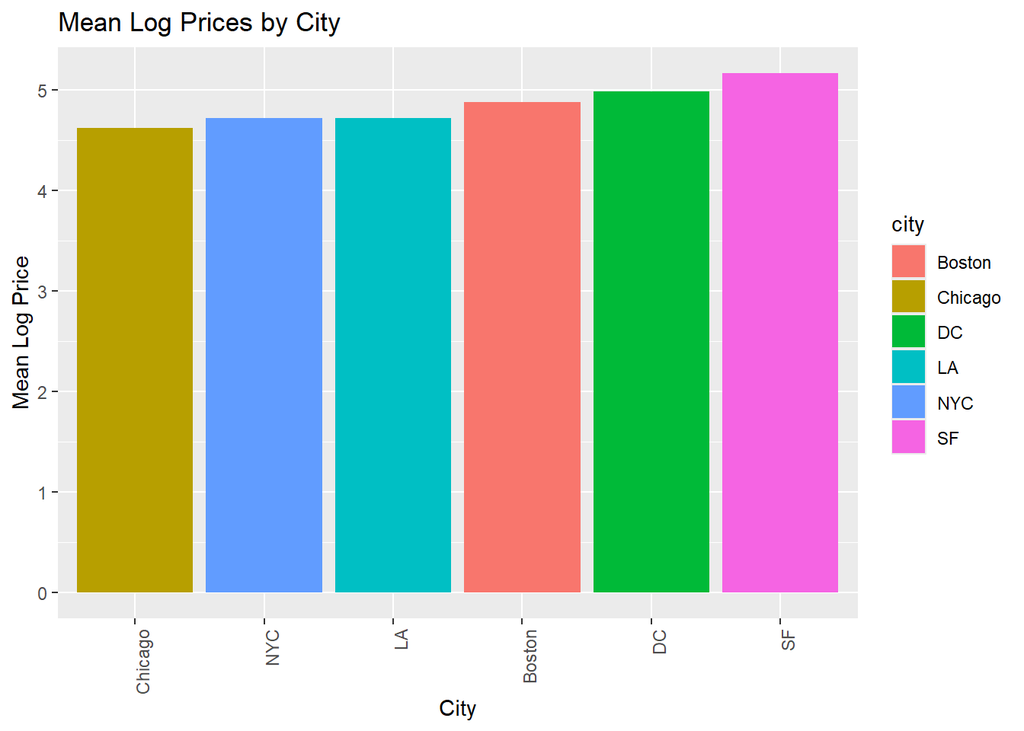

```r
library(ggplot2)

# Plotting mean log prices by city
ggplot(price_stats, aes(x = reorder(city, mean_log_price), y = mean_log_price, fill = city)) +
  geom_bar(stat = "identity") +
  theme(axis.text.x = element_text(angle = 90, hjust = 1)) +
  labs(title = "Mean Log Prices by City", x = "City", y = "Mean Log Price")
```

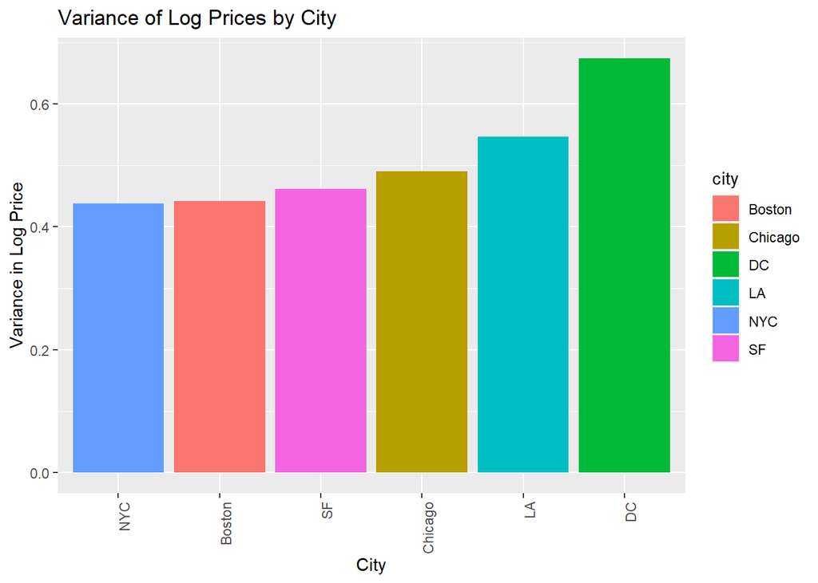

```r
# Plotting variance of log prices by city
ggplot(price_stats, aes(x = reorder(city, var_log_price), y = var_log_price, fill = city)) +
  geom_bar(stat = "identity") +
  theme(axis.text.x = element_text(angle = 90, hjust = 1)) +
  labs(title = "Variance of Log Prices by City", x = "City", y = "Variance in Log Price")
```

Slight difference can be found from different city’s price. Similar results can be found var room_type.

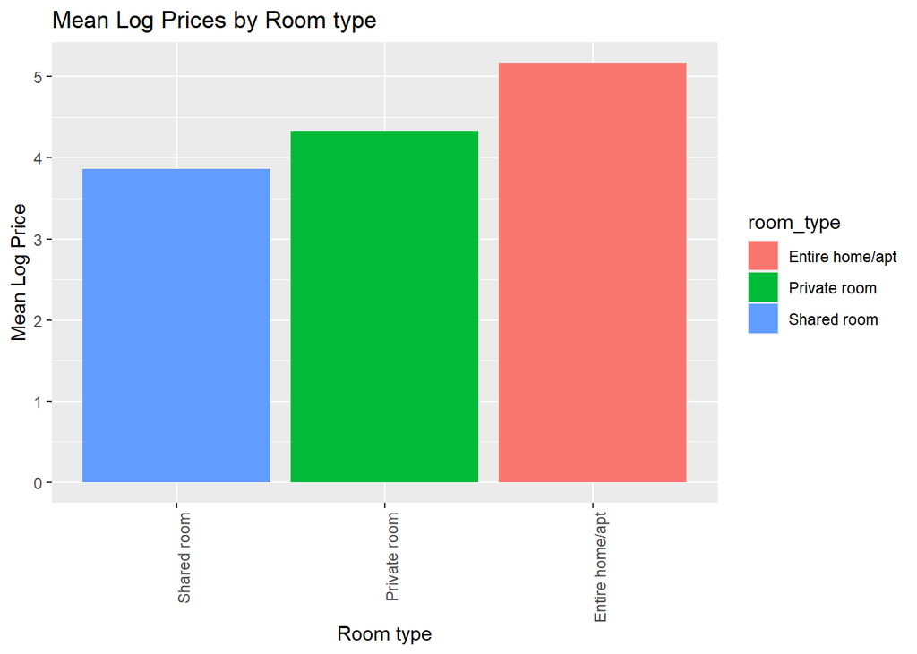

```r
# Calculating mean and variance of log_price for each room_type
price_stats2 <- DataSet %>%
  group_by(room_type) %>%
  summarize(
    mean_log_price2 = mean(log_price, na.rm = TRUE),
    var_log_price2 = var(log_price, na.rm = TRUE),
    count = n()
  )


ggplot(price_stats2, aes(x = reorder(room_type, mean_log_price2), y = mean_log_price2, fill = room_type)) +
  geom_bar(stat = "identity") +
  theme(axis.text.x = element_text(angle = 90, hjust = 1)) +
  labs(title = "Mean Log Prices by Room type", x = "Room type", y = "Mean Log Price")
```

[figure not shown]

```r
ggplot(price_stats2, aes(x = reorder(room_type, mean_log_price2), y = mean_log_price2, fill = room_type)) +
  geom_bar(stat = "identity") +
  theme(axis.text.x = element_text(angle = 90, hjust = 1)) +
  labs(title = "Variance of Log Prices by Room type", x = "Room type", y = "Variance in Log Price")
```

Also, T-test can be used to check the existence of differences.

```r
t.test(DataSet$log_price[DataSet$city == "NYC"],DataSet$log_price[DataSet$city == "LA"], alternative="less",var.equal = TRUE)
```

```
##
##  Two Sample t-test
##
## data:  DataSet$log_price[DataSet$city == "NYC"] and DataSet$log_price[DataSet$city == "LA"]
## t = -0.21408, df = 54615, p-value = 0.4152
## alternative hypothesis: true difference in means is less than 0
## 95 percent confidence interval:
##         -Inf 0.008644347
## sample estimates:
## mean of x mean of y
##  4.719238  4.720531
```

```r
t.test(DataSet$log_price[DataSet$city == "NYC"],DataSet$log_price[DataSet$city == "Boston"], alternative="less",var.equal = TRUE)
```

```
##
##  Two Sample t-test
##
## data:  DataSet$log_price[DataSet$city == "NYC"] and DataSet$log_price[DataSet$city == "Boston"]
## t = -13.927, df = 35639, p-value < 2.2e-16
## alternative hypothesis: true difference in means is less than 0
## 95 percent confidence interval:
##        -Inf -0.1453337
## sample estimates:
## mean of x mean of y
##  4.719238  4.884035
```

```r
t.test(DataSet$log_price[DataSet$room_type == "Private room"],DataSet$log_price[DataSet$room_type == "Shared room"], alternative="less",var.equal = TRUE)
```

```
##
##  Two Sample t-test
##
## data:  DataSet$log_price[DataSet$room_type == "Private room"] and DataSet$log_price[DataSet$room_type == "Shared room"]
## t = 41.153, df = 32698, p-value = 1
## alternative hypothesis: true difference in means is less than 0
## 95 percent confidence interval:
##       -Inf 0.4854585
## sample estimates:
## mean of x mean of y
##  4.327647  3.860847
```

```r
t.test(DataSet$log_price[DataSet$room_type == "Private room"],DataSet$log_price[DataSet$room_type == "Entire home/apt"], alternative="less",var.equal = TRUE)
```

```
##
##  Two Sample t-test
##
## data:  DataSet$log_price[DataSet$room_type == "Private room"] and DataSet$log_price[DataSet$room_type == "Entire home/apt"]
## t = -196.9, df = 71760, p-value < 2.2e-16
## alternative hypothesis: true difference in means is less than 0
## 95 percent confidence interval:
##        -Inf -0.8325653
## sample estimates:
## mean of x mean of y
##  4.327647  5.167226
```

From the results both in plots and T-test, we can see there are some difference of price between cities and room_type, which means that we can use other methods to find the detailed influence. Also, we can check multiple relationships by some visualizations.

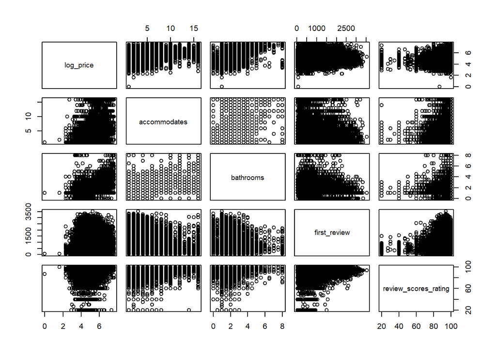

```r
pairs(DataSet[,c(1,4,5,10,20)])
```

We can see some slight linear relationship between log price and other variables. Also, whether the location in a city would influence the prices is a interesting problem. We can check this by clustering first and check means.

[figure not shown]

```r
library(dplyr)
# Determining the number of clusters with kmeans
set.seed(105)  # for reproducibility
coords <- DataSet %>% select(latitude, longitude)
k <- 6  # You might need to adjust this number based on the city's geographical spread and data distribution
clusters <- kmeans(coords, centers = k, nstart = 25)

# Adding cluster information back to the dataset
DataSet$cluster <- clusters$cluster

# Determining the number of clusters with kmeans
set.seed(105)  # for reproducibility
coords <- DataSet[DataSet$city=="NYC",] %>% select(latitude, longitude)
k <- 6  # You might need to adjust this number based on the city's geographical spread and data distribution
clusters <- kmeans(coords, centers = k, nstart = 25)

# Adding cluster information back to the dataset
DataSet[DataSet$city=="NYC",]$cluster <- clusters$cluster

# Visualizing clusters on a map
ggplot(DataSet[DataSet$city=="NYC",], aes(x = longitude, y = latitude, color = factor(cluster))) +
  geom_point(alpha = 0.5) +
  labs(title = "Geographical Clustering of Airbnb Listings", color = "Cluster")
```

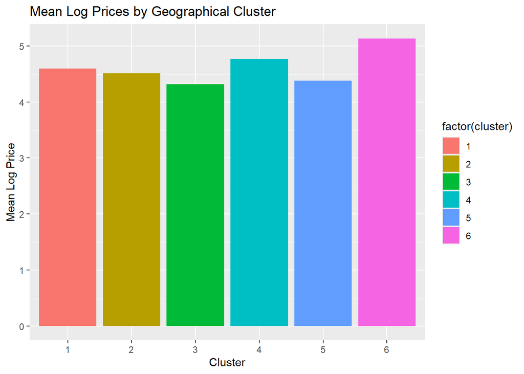

```r
# Calculating mean log_price for each cluster
cluster_price_stats <- DataSet[DataSet$city=="NYC",] %>%
  group_by(cluster) %>%
  summarize(
    mean_log_price = mean(log_price, na.rm = TRUE),
    count = n()
  )

# Plotting
ggplot(cluster_price_stats, aes(x = factor(cluster), y = mean_log_price, fill = factor(cluster))) +
  geom_bar(stat = "identity") +
  labs(title = "Mean Log Prices by Geographical Cluster", x = "Cluster", y = "Mean Log Price")
```

From the cluster results, we can see that the locations are not divided very reasonably by the k-means cluster method. It may need other methods to analysis the influence of location.

3.Application of different MVA models The multiple regression model can be used for price prediction.

```r
# Process categories variables
DataSetMR <- DataSet
DataSetMR$property_type <- as.factor(DataSetMR$property_type)
DataSetMR$room_type <- as.factor(DataSetMR$room_type)
DataSetMR$bed_type <- as.factor(DataSetMR$bed_type)
DataSetMR$cancellation_policy<- as.factor(DataSetMR$cancellation_policy)
DataSetMR$cleaning_fee<- as.factor(DataSetMR$cleaning_fee)
DataSetMR$city<- as.factor(DataSetMR$city)
DataSetMR$host_has_profile_pic<- as.factor(DataSetMR$host_has_profile_pic)
DataSetMR$host_identity_verified<- as.factor(DataSetMR$host_identity_verified)
DataSetMR$instant_bookable<-as.factor(DataSetMR$instant_bookable)
str(DataSetMR)
```

```
## tibble [73,923 × 23] (S3: tbl_df/tbl/data.frame)
##  $ log_price             : num [1:73923] 5.01 5.13 4.98 6.62 4.74 ...
##  $ property_type         : Factor w/ 35 levels "Apartment","Bed & Breakfast",..: 1 1 1 18 1 1 1 12 18 18 ...
##  $ room_type             : Factor w/ 3 levels "Entire home/apt",..: 1 1 1 1 1 2 1 1 2 2 ...
##  $ accommodates          : num [1:73923] 3 7 5 4 2 2 3 2 2 2 ...
##  $ bathrooms             : num [1:73923] 1 1 1 1 1 1 1 1 1 1 ...
##  $ bed_type              : Factor w/ 5 levels "Airbed","Couch",..: 5 5 5 5 5 5 5 5 5 5 ...
##  $ cancellation_policy   : Factor w/ 5 levels "flexible","moderate",..: 3 3 2 1 2 3 2 2 2 2 ...
##  $ cleaning_fee          : Factor w/ 2 levels "FALSE","TRUE": 2 2 2 2 2 2 2 2 2 2 ...
##  $ city                  : Factor w/ 6 levels "Boston","Chicago",..: 5 5 5 6 3 6 4 4 6 4 ...
##  $ first_review          : num [1:73923] 501 88 185 927 904 66 236 320 627 212 ...
##  $ host_has_profile_pic  : Factor w/ 2 levels "FALSE","TRUE": 2 2 2 2 2 2 2 2 2 2 ...
##  $ host_identity_verified: Factor w/ 2 levels "FALSE","TRUE": 2 1 2 2 2 2 1 2 1 1 ...
##  $ host_response_rate    : num [1:73923] 94.4 100 100 94.4 100 ...
##  $ host_since            : num [1:73923] 2046 135 372 927 976 ...
##  $ instant_bookable      : Factor w/ 2 levels "FALSE","TRUE": 1 2 2 1 2 2 2 1 1 2 ...
##  $ last_review           : num [1:73923] 471 39 48 927 283 57 194 203 38 199 ...
##  $ latitude              : num [1:73923] 40.7 40.8 40.8 37.8 38.9 ...
##  $ longitude             : num [1:73923] -74 -74 -73.9 -122.4 -77 ...
##  $ number_of_reviews     : num [1:73923] 2 6 10 0 4 3 15 9 159 2 ...
##  $ review_scores_rating  : num [1:73923] 100 93 92 94.1 40 ...
##  $ bedrooms              : num [1:73923] 1 3 1 2 0 1 1 1 1 1 ...
##  $ beds                  : num [1:73923] 1 3 3 2 1 1 1 1 1 1 ...
##  $ cluster               : int [1:73923] 6 6 5 3 2 3 6 6 3 6 ...
```

The property_type has lots of categories, we can check it’s distribution by simple analysis.

```r
xtabs(~ room_type + property_type, data=DataSetMR)
```

```
##                  property_type
## room_type         Apartment Bed & Breakfast  Boat Boutique hotel Bungalow Cabin
##   Entire home/apt     28820              57    56             22      313    58
##   Private room        18648             361     9             47       51    12
##   Shared room          1372              43     0              0        2     1
##                  property_type
## room_type         Camper/RV Casa particular Castle  Cave Chalet Condominium
##   Entire home/apt        73               0      7     1      3        1631
##   Private room           17               1      6     1      3         984
##   Shared room             4               0      0     0      0          39
##                  property_type
## room_type          Dorm Earth House Guest suite Guesthouse Hostel House   Hut
##   Entire home/apt     3           3          71        412      2  7513     5
##   Private room       66           1          52         68     23  8540     2
##   Shared room        73           0           0         18     45   450     1
##                  property_type
## room_type         In-law Island Lighthouse  Loft Other Parking Space
##   Entire home/apt     62      0          1   784   353             0
##   Private room         8      1          0   408   223             0
##   Shared room          1      0          0    49    31             1
##                  property_type
## room_type         Serviced apartment  Tent Timeshare  Tipi Townhouse Train
##   Entire home/apt                 16     6        59     2       787     1
##   Private room                     5    11        17     1       872     1
##   Shared room                      0     1         0     0        26     0
##                  property_type
## room_type         Treehouse Vacation home Villa  Yurt
##   Entire home/apt         4             9    83     6
##   Private room            3             2    92     3
##   Shared room             0             0     4     0
```

From the result, many of them are very rare in the data. So we can just combine them into a few board categories, namely apartment, house and others.

```r
DataSetMR <- DataSetMR %>%
  mutate(broad_category = case_when(
    property_type %in% c('Apartment', 'Condominium', 'Loft', 'Serviced apartment') ~ 'Apartment',
    property_type %in% c('House', 'Villa', 'Townhouse', 'Bungalow', 'Cottage', 'Chalet', 'In-law') ~ 'House',
    property_type %in% c('Boat', 'Boutique hotel', 'Casa particular', 'Castle', 'Cave', 'Dorm', 'Earth House', 'Guest suite', 'Guesthouse', 'Hostel', 'Hut', 'Island', 'Lighthouse', 'Tent', 'Tipi', 'Train', 'Treehouse', 'Yurt') ~ 'Unique Stays',
    TRUE ~ 'Other'  # Default category
  ))
xtabs(~ room_type + broad_category, data=DataSetMR)
```

```
##                  broad_category
## room_type         Apartment House Other Unique Stays
##   Entire home/apt     31251  8761   609          602
##   Private room        20045  9566   632          296
##   Shared room          1460   483    80          138
```

```r
DataSetMR$property_type<-DataSetMR$broad_category
DataSetMR$broad_category<-NULL
```

```r
DataSetMR$property_type<-as.factor(DataSetMR$property_type)
str(DataSetMR)
```

```
## tibble [73,923 × 23] (S3: tbl_df/tbl/data.frame)
##  $ log_price             : num [1:73923] 5.01 5.13 4.98 6.62 4.74 ...
##  $ property_type         : Factor w/ 4 levels "Apartment","House",..: 1 1 1 2 1 1 1 1 2 2 ...
##  $ room_type             : Factor w/ 3 levels "Entire home/apt",..: 1 1 1 1 1 2 1 1 2 2 ...
##  $ accommodates          : num [1:73923] 3 7 5 4 2 2 3 2 2 2 ...
##  $ bathrooms             : num [1:73923] 1 1 1 1 1 1 1 1 1 1 ...
##  $ bed_type              : Factor w/ 5 levels "Airbed","Couch",..: 5 5 5 5 5 5 5 5 5 5 ...
##  $ cancellation_policy   : Factor w/ 5 levels "flexible","moderate",..: 3 3 2 1 2 3 2 2 2 2 ...
##  $ cleaning_fee          : Factor w/ 2 levels "FALSE","TRUE": 2 2 2 2 2 2 2 2 2 2 ...
##  $ city                  : Factor w/ 6 levels "Boston","Chicago",..: 5 5 5 6 3 6 4 4 6 4 ...
##  $ first_review          : num [1:73923] 501 88 185 927 904 66 236 320 627 212 ...
##  $ host_has_profile_pic  : Factor w/ 2 levels "FALSE","TRUE": 2 2 2 2 2 2 2 2 2 2 ...
##  $ host_identity_verified: Factor w/ 2 levels "FALSE","TRUE": 2 1 2 2 2 2 1 2 1 1 ...
##  $ host_response_rate    : num [1:73923] 94.4 100 100 94.4 100 ...
##  $ host_since            : num [1:73923] 2046 135 372 927 976 ...
##  $ instant_bookable      : Factor w/ 2 levels "FALSE","TRUE": 1 2 2 1 2 2 2 1 1 2 ...
##  $ last_review           : num [1:73923] 471 39 48 927 283 57 194 203 38 199 ...
##  $ latitude              : num [1:73923] 40.7 40.8 40.8 37.8 38.9 ...
##  $ longitude             : num [1:73923] -74 -74 -73.9 -122.4 -77 ...
##  $ number_of_reviews     : num [1:73923] 2 6 10 0 4 3 15 9 159 2 ...
##  $ review_scores_rating  : num [1:73923] 100 93 92 94.1 40 ...
##  $ bedrooms              : num [1:73923] 1 3 1 2 0 1 1 1 1 1 ...
##  $ beds                  : num [1:73923] 1 3 3 2 1 1 1 1 1 1 ...
##  $ cluster               : int [1:73923] 6 6 5 3 2 3 6 6 3 6 ...
```

Let’s check other category variables distribution.

```r
xtabs(~ room_type + bed_type, data=DataSetMR)
```

```
##                  bed_type
## room_type         Airbed Couch Futon Pull-out Sofa Real Bed
##   Entire home/apt    100    53   168           211    40691
##   Private room       275    61   485           256    29462
##   Shared room        102   153    97           115     1694
```

```r
xtabs(~ room_type + cancellation_policy, data=DataSetMR)
```

```
##                  cancellation_policy
## room_type         flexible moderate strict super_strict_30 super_strict_60
##   Entire home/apt     9762    10544  20788             112              17
##   Private room       11767     8079  10693               0               0
##   Shared room          955      391    815               0               0
```

```r
xtabs(~ room_type + cleaning_fee, data=DataSetMR)
```

```
##                  cleaning_fee
## room_type         FALSE  TRUE
##   Entire home/apt  7555 33668
##   Private room    11069 19470
##   Shared room      1035  1126
```

```r
xtabs(~ room_type + city, data=DataSetMR)
```

```
##                  city
## room_type         Boston Chicago    DC    LA   NYC    SF
##   Entire home/apt   2146    2217  3882 12998 16163  3817
##   Private room      1276    1401  1668  8472 15205  2517
##   Shared room         46     101   137   974   805    98
```

```r
xtabs(~ room_type + host_has_profile_pic, data=DataSetMR)
```

```
##                  host_has_profile_pic
## room_type         FALSE  TRUE
##   Entire home/apt   127 41096
##   Private room       90 30449
##   Shared room         9  2152
```

```r
xtabs(~ room_type + host_identity_verified, data=DataSetMR)
```

```
##                  host_identity_verified
## room_type         FALSE  TRUE
##   Entire home/apt 12336 28887
##   Private room    10933 19606
##   Shared room       906  1255
```

```r
xtabs(~ room_type + instant_bookable, data=DataSetMR)
```

```
##                  instant_bookable
## room_type         FALSE  TRUE
##   Entire home/apt 30779 10444
##   Private room    22257  8282
##   Shared room      1479   682
```

We can see that there are some 0s in cancellation_policy. We can merge the last 3 types as strict.

```r
DataSetMR <- DataSetMR %>%
  mutate(broad_category = case_when(
    cancellation_policy %in% c('flexible') ~ 'flexible',
    cancellation_policy %in% c('moderate') ~ 'moderate',
    cancellation_policy %in% c('strict', 'super_strict_30', 'super_strict_60') ~ 'strict',
  ))
xtabs(~ room_type + broad_category, data=DataSetMR)
```

```
##                  broad_category
## room_type         flexible moderate strict
##   Entire home/apt     9762    10544  20917
##   Private room       11767     8079  10693
##   Shared room          955      391    815
```

```r
DataSetMR$cancellation_policy<-DataSetMR$broad_category
DataSetMR$broad_category<-NULL
DataSetMR$cancellation_policy<- as.factor(DataSetMR$cancellation_policy)
```

Now we can try to run the multiple regression.

```r
# Standardize the dataset (excluding non-numeric and factor variables)
numeric_cols <- sapply(DataSetMR, is.numeric)
DataSetMR_normalized <- as.data.frame(scale(DataSetMR[, numeric_cols]))
factor_cols <- sapply(DataSetMR, is.factor)
DataSetMR_normalized <- cbind(DataSetMR_normalized, DataSetMR[, factor_cols])
DataSetMR_normalized$cluster <-NULL
fit <- lm(log_price~., data=DataSetMR_normalized)
summary(fit)
```

```
##
## Call:
## lm(formula = log_price ~ ., data = DataSetMR_normalized)
##
## Residuals:
##     Min      1Q  Median      3Q     Max
## -5.0868 -0.4092 -0.0357  0.3555  5.6337
##
## Coefficients:
##                               Estimate Std. Error  t value Pr(>|t|)
## (Intercept)                  29.248008   0.600812   48.681  < 2e-16 ***
## accommodates                  0.273277   0.004733   57.739  < 2e-16 ***
## bathrooms                     0.109863   0.003081   35.664  < 2e-16 ***
## first_review                  0.050307   0.004387   11.467  < 2e-16 ***
## host_response_rate           -0.022973   0.002441   -9.412  < 2e-16 ***
## host_since                   -0.012076   0.003161   -3.820 0.000134 ***
## last_review                   0.055619   0.003949   14.085  < 2e-16 ***
## latitude                      0.439013   0.107776    4.073 4.64e-05 ***
## longitude                   -29.682742   0.583046  -50.910  < 2e-16 ***
## number_of_reviews            -0.037284   0.003188  -11.697  < 2e-16 ***
## review_scores_rating          0.062223   0.002419   25.726  < 2e-16 ***
## bedrooms                      0.164799   0.003909   42.154  < 2e-16 ***
## beds                         -0.083314   0.004403  -18.921  < 2e-16 ***
## property_typeHouse           -0.026082   0.006361   -4.101 4.12e-05 ***
## property_typeOther            0.164041   0.018252    8.988  < 2e-16 ***
## property_typeUnique Stays    -0.147914   0.020725   -7.137 9.62e-13 ***
## room_typePrivate room        -0.832712   0.005918 -140.701  < 2e-16 ***
## room_typeShared room         -1.444050   0.015385  -93.862  < 2e-16 ***
## bed_typeCouch                 0.202804   0.049919    4.063 4.86e-05 ***
## bed_typeFuton                -0.018888   0.038075   -0.496 0.619852
## bed_typePull-out Sofa         0.083466   0.040135    2.080 0.037561 *
## bed_typeReal Bed              0.085573   0.030014    2.851 0.004359 **
## cancellation_policymoderate  -0.032916   0.006855   -4.802 1.57e-06 ***
## cancellation_policystrict     0.017643   0.006361    2.774 0.005545 **
## cleaning_feeTRUE             -0.054722   0.005999   -9.122  < 2e-16 ***
## cityChicago                 -23.045924   0.446837  -51.576  < 2e-16 ***
## cityDC                       -7.617708   0.206776  -36.840  < 2e-16 ***
## cityLA                      -63.654096   1.321949  -48.152  < 2e-16 ***
## cityNYC                      -3.756324   0.099393  -37.793  < 2e-16 ***
## citySF                      -69.149846   1.399629  -49.406  < 2e-16 ***
## host_has_profile_picTRUE     -0.141855   0.043393   -3.269 0.001079 **
## host_identity_verifiedTRUE   -0.042862   0.005556   -7.714 1.23e-14 ***
## instant_bookableTRUE         -0.022839   0.005690   -4.014 5.98e-05 ***
## ---
## Signif. codes:  0 '***' 0.001 '**' 0.01 '*' 0.05 '.' 0.1 ' ' 1
##
## Residual standard error: 0.6491 on 73890 degrees of freedom
## Multiple R-squared:  0.5789, Adjusted R-squared:  0.5787
## F-statistic:  3174 on 32 and 73890 DF,  p-value: < 2.2e-16
```

```r
DataSetMR2 <- DataSetMR_normalized
DataSetMR2 <- DataSetMR2 %>%
  mutate(broad_category = case_when(
    property_type %in% c('House','Apartment') ~ 'House/Apt',
    property_type %in% c('Other') ~ 'Other',
    property_type %in% c('Unique Stays') ~ 'Unique Stays'
  ))
DataSetMR2$property_type<-DataSetMR2$broad_category
DataSetMR2$broad_category<-NULL

DataSetMR2 <- DataSetMR2 %>%
  mutate(broad_category = case_when(
    bed_type %in% c('Real Bed') ~ 'Real Bed',
    bed_type %in% c('Pull-out Sofa','Airbed','Couch','Futon') ~ 'Other'
  ))
DataSetMR2$bed_type<-DataSetMR2$broad_category
DataSetMR2$broad_category<-NULL

DataSetMR2 <- DataSetMR2 %>%
  mutate(broad_category = case_when(
    cancellation_policy %in% c('flexible') ~ 'flexible',
    cancellation_policy %in% c('moderate','strict') ~ 'moderate/strict'
  ))
DataSetMR2$cancellation_policy<-DataSetMR2$broad_category
DataSetMR2$broad_category<-NULL

DataSetMR2$host_since<-NULL
DataSetMR2$cancellation_policy <-NULL
fit2 <- lm(log_price~., data=DataSetMR2)
summary(fit2)
```

```
##
## Call:
## lm(formula = log_price ~ ., data = DataSetMR2)
##
## Residuals:
##     Min      1Q  Median      3Q     Max
## -5.0743 -0.4097 -0.0357  0.3561  5.6159
##
## Coefficients:
##                              Estimate Std. Error  t value Pr(>|t|)
## (Intercept)                 29.510709   0.598271   49.327  < 2e-16 ***
## accommodates                 0.274852   0.004729   58.126  < 2e-16 ***
## bathrooms                    0.108939   0.003063   35.564  < 2e-16 ***
## first_review                 0.043438   0.003877   11.205  < 2e-16 ***
## host_response_rate          -0.023557   0.002438   -9.661  < 2e-16 ***
## last_review                  0.057329   0.003856   14.866  < 2e-16 ***
## latitude                     0.469393   0.107767    4.356 1.33e-05 ***
## longitude                  -29.945648   0.580588  -51.578  < 2e-16 ***
## number_of_reviews           -0.037664   0.003182  -11.837  < 2e-16 ***
## review_scores_rating         0.060655   0.002415   25.120  < 2e-16 ***
## bedrooms                     0.162782   0.003885   41.902  < 2e-16 ***
## beds                        -0.082977   0.004402  -18.850  < 2e-16 ***
## property_typeOther           0.172636   0.018159    9.507  < 2e-16 ***
## property_typeUnique Stays   -0.142209   0.020631   -6.893 5.50e-12 ***
## room_typePrivate room       -0.838806   0.005773 -145.301  < 2e-16 ***
## room_typeShared room        -1.432679   0.015241  -94.001  < 2e-16 ***
## bed_typeReal Bed             0.047190   0.014833    3.181 0.001466 **
## cleaning_feeTRUE            -0.055430   0.005773   -9.601  < 2e-16 ***
## cityChicago                -23.245231   0.444999  -52.237  < 2e-16 ***
## cityDC                      -7.664944   0.206408  -37.135  < 2e-16 ***
## cityLA                     -64.152643   1.317369  -48.698  < 2e-16 ***
## cityNYC                     -3.774646   0.099272  -38.023  < 2e-16 ***
## citySF                     -69.734870   1.394238  -50.016  < 2e-16 ***
## host_has_profile_picTRUE    -0.143900   0.043421   -3.314 0.000920 ***
## host_identity_verifiedTRUE  -0.048705   0.005340   -9.121  < 2e-16 ***
## instant_bookableTRUE        -0.019855   0.005678   -3.497 0.000472 ***
## ---
## Signif. codes:  0 '***' 0.001 '**' 0.01 '*' 0.05 '.' 0.1 ' ' 1
##
## Residual standard error: 0.6496 on 73897 degrees of freedom
## Multiple R-squared:  0.5781, Adjusted R-squared:  0.578
## F-statistic:  4051 on 25 and 73897 DF,  p-value: < 2.2e-16
```

```r
coefficients(fit2)
```

```
##                (Intercept)               accommodates
##                29.51070890                 0.27485198
##                  bathrooms               first_review
##                 0.10893871                 0.04343812
##         host_response_rate                last_review
##                -0.02355706                 0.05732861
##                   latitude                  longitude
##                 0.46939271               -29.94564776
##          number_of_reviews       review_scores_rating
##                -0.03766385                 0.06065545
##                   bedrooms                       beds
##                 0.16278239                -0.08297697
##         property_typeOther  property_typeUnique Stays
##                 0.17263609                -0.14220902
##      room_typePrivate room       room_typeShared room
##                -0.83880579                -1.43267918
##           bed_typeReal Bed           cleaning_feeTRUE
##                 0.04719036                -0.05543024
##                cityChicago                     cityDC
##               -23.24523069                -7.66494418
##                     cityLA                    cityNYC
##               -64.15264317                -3.77464607
##                     citySF   host_has_profile_picTRUE
##               -69.73487033                -0.14390002
## host_identity_verifiedTRUE       instant_bookableTRUE
##                -0.04870497                -0.01985495
```

Now We can analysis the results to get some insights from the model.

4.Model Insights From the results, there are several intuitive insights. Such as: a. More bathrooms, bedrooms, accommodates can increase the price. b. However, more beds can lead to lower price. It may because more beds implied sharing room. c. Shared room and Private room can decrease the price compared with Entire Home/Apt

Also, there are some interesting results. Firstly, in property_type, others will increase the price while unique stays decrease the price. We can see some fantastic types in unique stays, such as castle, island. But actually their price is lower than normal house. It may because that this type of lodges normally locates far away from the city center.

What’s more, the latitude and longitude is significantly influencing the price. Which is wield. From the early analysis, we can see that dealing with location related number is difficult. This kind of influence may comes from the city differences.

5.Learnings and Takeaways There are some following direction can be explore afterwards. First, the influence of property_type can be analyzed further, since the board classification is still crude. Second, the location of data, namely the latitude and longitude can be explored more. Classic cluster and regression methods may not able to deal with this part. Furthermore, about the text type of data, we can use text mining methods to put them to use.